# Devoir_E_CHAUVET_DUBAUT

Etude de la base de données BDD_data

CHAUVET Benjamin & DUBAUT Damien

```r
library(data.table)
library(kableExtra)
library(knitr)
library(ggplot2)
library(gridExtra)
library(dplyr)
library(corrplot)
library(lmtest)
library(ggcorrplot)
library(ggpubr)
library(GGally)
```

```r
data <- read.csv("~/BDD_data.csv", quote=",")
```

```r
data <- data[,-1]
```

On retire la variable **id**

# **Introduction**

## Présentation de la base de données

Notre base de données contient 21 613 observations sur la vente de maisons entre 2014 et 2015, elle contient ici 20 variables :

1. **date**: Date house was sold
2. **price**: Price of the sold house
3. **bedrooms**: Number of Bedrooms
4. **bathrooms**: Number of bathrooms
5. **sqft_living**: Square footage of the living space
6. **sqrt_lot**: Square footage of the lot
7. **floors**: Total floors in the house
8. **waterfront**: Whether the house is on a waterfront(1: yes, 0: no)
9. **view**: special view?
10. **condition**: Condition of the house
11. **grade**: unknown
12. **sqft_above**: Square footage of house apart from basement
13. **sqft_basement**: Square footage of the basement
14. **yr_built**: Built year
15. **yr_renovated**: Year when the house was renovated
16. **zipcode**: zipcode of the house
17. **lat**: Latitude coordinate
18. **long** Longitude coordinate
19. **sqft_living15**: Living room area in 2015(implies some renovations)
20. **sqrt_lot15**: Lot area in 2015(implies some renovations)

```r
str(data)
```

```
## 'data.frame':    21613 obs. of  20 variables:
##  $ date         : chr  "\"\"20141013T000000\"\"" "\"\"20141209T000000\"\"" "\"\"20150225T000000\"\"" "\"\"20141209T000000\"\"" ...
##  $ price        : num  221900 538000 180000 604000 510000 ...
##  $ bedrooms     : int  3 3 2 4 3 4 3 3 3 3 ...
##  $ bathrooms    : num  1 2.25 1 3 2 4.5 2.25 1.5 1 2.5 ...
##  $ sqft_living  : int  1180 2570 770 1960 1680 5420 1715 1060 1780 1890 ...
##  $ sqft_lot     : int  5650 7242 10000 5000 8080 101930 6819 9711 7470 6560 ...
##  $ floors       : chr  "\"\"1\"\"" "\"\"2\"\"" "\"\"1\"\"" "\"\"1\"\"" ...
##  $ waterfront   : int  0 0 0 0 0 0 0 0 0 0 ...
##  $ view         : int  0 0 0 0 0 0 0 0 0 0 ...
##  $ condition    : int  3 3 3 5 3 3 3 3 3 3 ...
##  $ grade        : int  7 7 6 7 8 11 7 7 7 7 ...
##  $ sqft_above   : int  1180 2170 770 1050 1680 3890 1715 1060 1050 1890 ...
##  $ sqft_basement: int  0 400 0 910 0 1530 0 0 730 0 ...
##  $ yr_built     : int  1955 1951 1933 1965 1987 2001 1995 1963 1960 2003 ...
##  $ yr_renovated : int  0 1991 0 0 0 0 0 0 0 0 ...
##  $ zipcode      : chr  "\"\"98178\"\"" "\"\"98125\"\"" "\"\"98028\"\"" "\"\"98136\"\"" ...
##  $ lat          : num  47.5 47.7 47.7 47.5 47.6 ...
##  $ long         : num  -122 -122 -122 -122 -122 ...
##  $ sqft_living15: int  1340 1690 2720 1360 1800 4760 2238 1650 1780 2390 ...
##  $ sqft_lot15   : chr  "5650\"" "7639\"" "8062\"" "5000\"" ...
```

Nous recodons les variables character en facteurs :

```r
data$date<-as.factor(data$date)
data$date<-as.numeric(data$date)

data$floors<-as.factor(data$floors)
data$floors<-as.numeric(data$floors)

data$zipcode<-as.factor(data$zipcode)
data$zipcode<-as.numeric(data$zipcode)

data$sqft_lot15<-as.factor(data$sqft_lot15)
data$sqft_lot15<-as.numeric(data$sqft_lot15)
```

## Situation temporelle de l’étude

La vente des maisons a eu lieu en 2014 et 2015.

Regardons les années de construction des maisons de cette base de données :

```r
summary(data$yr_built)
```

```
##    Min. 1st Qu.  Median    Mean 3rd Qu.    Max.
##    1900    1951    1975    1971    1997    2015
```

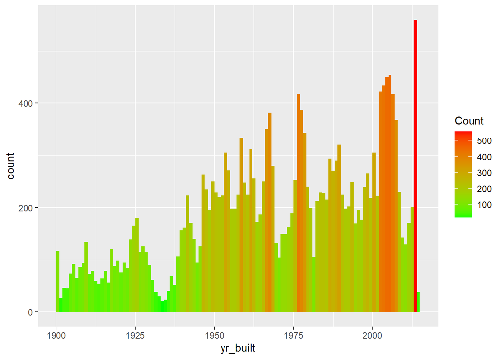

```r
ggplot(data, aes(x=yr_built))+
  geom_histogram(breaks=seq(1900, 2015, by=1), aes(fill=..count..))+
  scale_fill_gradient("Count", low="green", high="red")
```

Les années de construction des maisons s’étendent de 1900 à 2015 avec une forte concentration à partir des années 2000 et particulièrement en 2014.

```r
mean(data$yr_renovated==0)
```

```
## [1] 0.9577106
```

```r
mean(data$yr_renovated!=0)
```

```
## [1] 0.04228936
```

On remarque que seulement 4% des maisons de la base de données ont été rénovées. Cette variable sera donc peu significative.

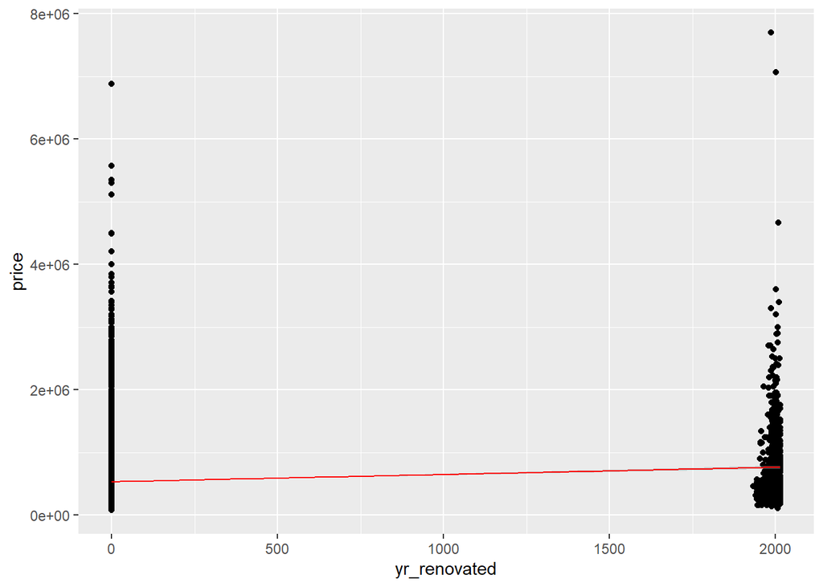

```r
par(mfrow=c(2,1))
ggplot(data, aes(x=yr_renovated, y=price))+
  geom_point()+
  geom_smooth(method="lm", color = 'red', size = 0.5)
```

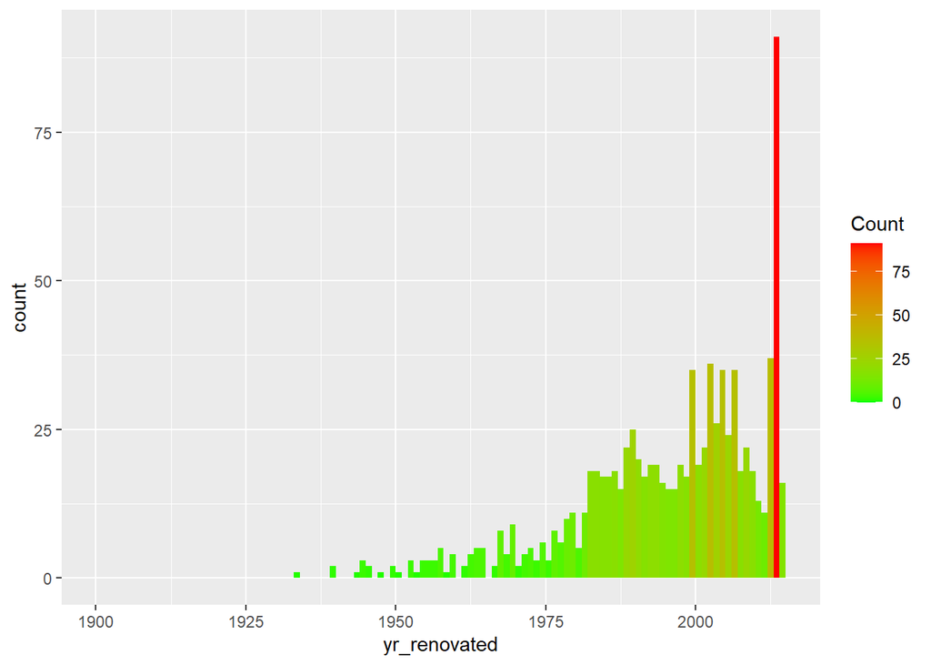

```r
ggplot(data, aes(x=yr_renovated))+
  geom_histogram(breaks=seq(1900, 2015, by=1), aes(fill=..count..))+
  scale_fill_gradient("Count", low="green", high="red")
```

On peut quand même dire que le prix des maisons qui ont été rénovées à tendance à être plus élévé que pour les maisons non rénovées. On voit aussi que pour les maisons rénovées, il y a une forte concentration en 2014.

## Statistiques descriptives axés sur les caractéristiques des maisons

```r
df_S <- data.frame(
  variable = c("bedroom","bathrooms",
               "surface habitable","surface habitable (hors sous-sol)","Etage"),
  Moyenne = c(mean(data$bedrooms),
              mean(data$bathrooms),
              mean(data$sqft_living),
              mean(data$sqft_above),
              mean(data$floors)),
  médiane = c(quantile(data$bedrooms,0.5),
              quantile(data$bathrooms,0.5),
              quantile(data$sqft_living,0.5),
              quantile(data$sqft_above,0.5),
              quantile(data$floors,0.5)),
  sd = c(sd(data$bedrooms),
         sd(data$bathrooms),
         sd(data$sqft_living),
         sd(data$sqft_above),
         sd(data$floors)),
  min = c(min(data$bedrooms),
          min(data$bathrooms),
          min(data$sqft_living),
          min(data$sqft_above),
          min(data$floors)),
  max = c(max(data$bedrooms),
          max(data$bathrooms),
          max(data$sqft_living),
          max(data$sqft_above),
          max(data$floors))
)

df_S
```

| variable | Moyenne | médiane | sd | min | max |
| --- | --- | --- | --- | --- | --- |
| bedroom | 3.370842 | 3.00 | 0.9300618 | 0 | 33 |
| bathrooms | 2.114757 | 2.25 | 0.7701632 | 0 | 8 |
| surface habitable | 2079.899736 | 1910.00 | 918.4408970 | 290 | 13540 |
| surface habitable (hors sous-sol) | 1788.390691 | 1560.00 | 828.0909777 | 290 | 9410 |
| Etage | 1.988618 | 2.00 | 1.0799778 | 1 | 6 |

La variable **price** sur le prix de vente de la maison sera notre variable centrale

```r
summary(data$price)
```

```
##    Min. 1st Qu.  Median    Mean 3rd Qu.    Max.
##   75000  321950  450000  540088  645000 7700000
```

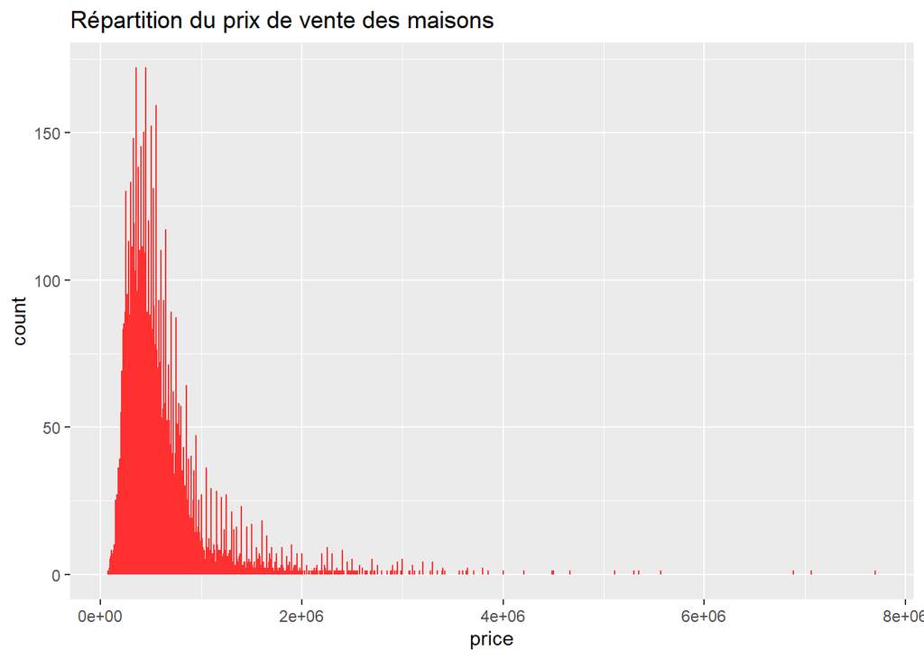

```r
ggplot(data, aes(x=price))+
  geom_bar(color="firebrick1")+
  ggtitle("Répartition du prix de vente des maisons")
```

Visualisons maintenant nos différentes variables liées aux caractéristiques des maisons :

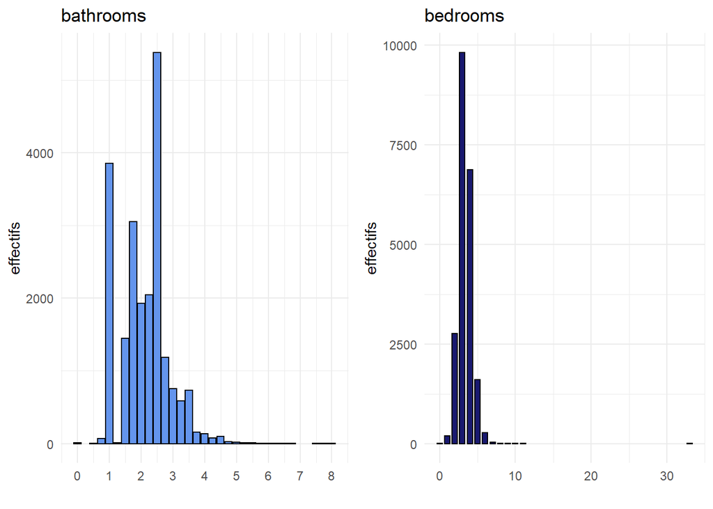

```r
h <- ggplot(data, aes(x=bathrooms))+
  geom_bar(stat="count", fill="cornflowerblue", color="black")+
  theme_minimal()+
  ggtitle("bathrooms")+
  scale_x_continuous(breaks = seq(0, 8, by = 1))+
  labs(x="", y="effectifs")

g <- ggplot(data, aes(x=bedrooms))+
  geom_bar(stat="count", width=0.7, position="dodge", fill="midnightblue", color="black")+
  theme_minimal()+
  ggtitle("bedrooms")+
  labs(x="", y="effectifs")

grid.arrange(h, g, nrow=1)
```

```r
summary(data$bedrooms)
```

```
##    Min. 1st Qu.  Median    Mean 3rd Qu.    Max.
##   0.000   3.000   3.000   3.371   4.000  33.000
```

On voit que la variable bathrooms n’est pas entière. Mais on décide de la laisser comme ca pour pas que l’arrondi à l’entier fausse nos résulats.

La variable bedrooms comporte une valeur extrême (33 chambres, correspondant à l’observation 15871) ce qui pourrait être une valeur abérrante dans nos futurs modèles. On décide donc de la retirer.

```r
data <- data[-15871,]
```

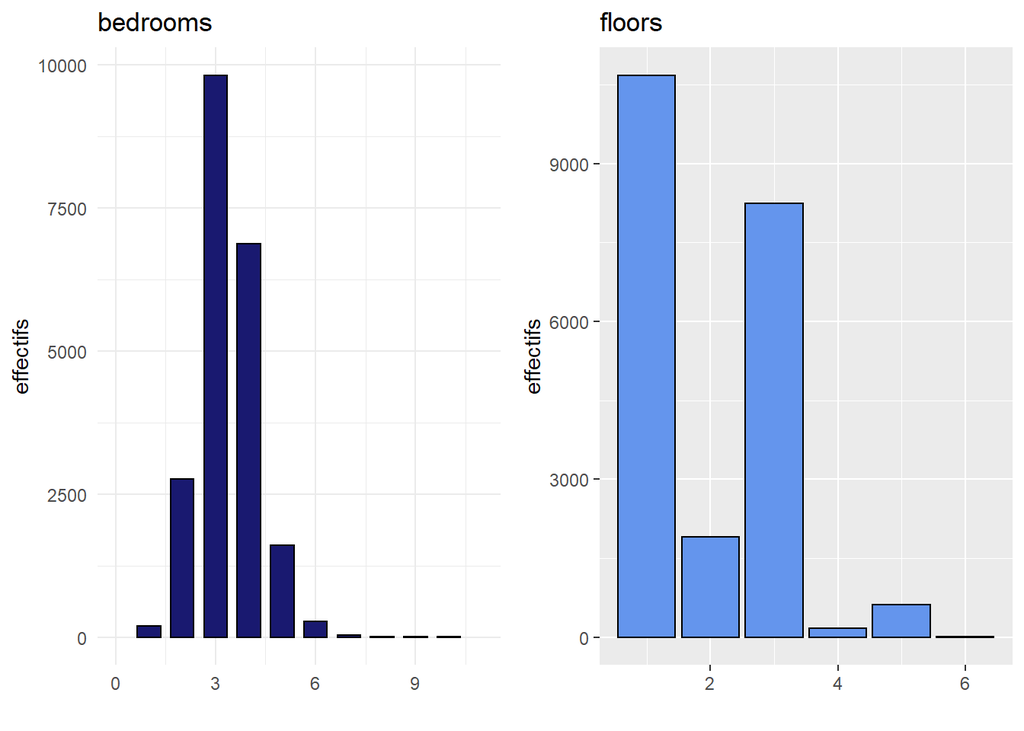

```r
d<-ggplot(data, aes(x=bedrooms))+
  geom_bar(stat="count", width=0.7, position="dodge", fill="midnightblue", color="black")+
  theme_minimal()+
  ggtitle("bedrooms")+
  labs(x="", y="effectifs")+
  xlim(0,11)

e<-ggplot(data, aes(x=floors))+
  geom_bar(fill="cornflowerblue", color="black")+
  ggtitle("floors")+
  labs(x="", y="effectifs")


grid.arrange(d,e, nrow=1)
```

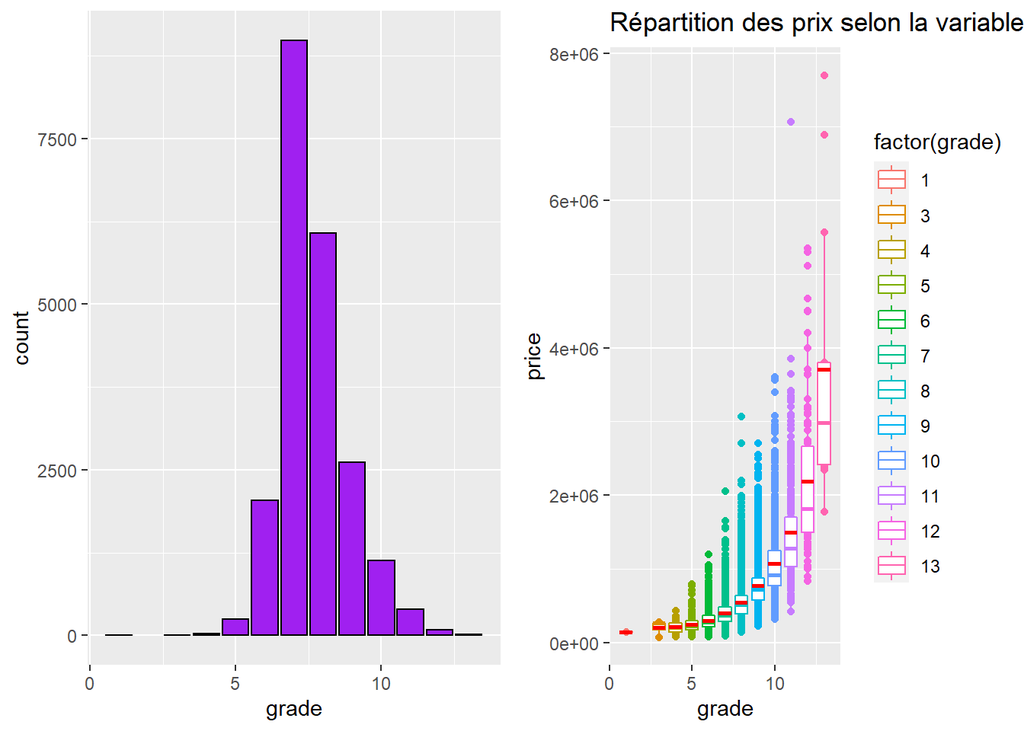

```r
k <- ggplot(data, aes(x=grade))+
  geom_bar(fill="purple", color="black")

l <- ggplot(data, aes(x=grade, y=price))+
  geom_point(aes(colour = factor(grade)))+
  geom_boxplot(aes(colour=factor(grade)))+
  stat_summary(fun.y="mean", geom="crossbar", size=0.4, width=0.75, color="red")+
  ggtitle("Répartition des prix selon la variable grade")

grid.arrange(k,l, nrow=1)
```

On ne sait pas à quoi correspond la variable grade mais quand on regarde le graphique des prix en fonction de cette variable, le prix augmente de façon exponentielle quand grade augmente.

On regardera les corrélations de cette variable pour en déduire à quoi elle correspond.

On sait que la variable **sqft_living** sur la surface habitable correspond à : **sqft_above** + **sqft_basement**

Commençons par comparer les surfaces habitables initiales avec les surfaces habitables en 2015.

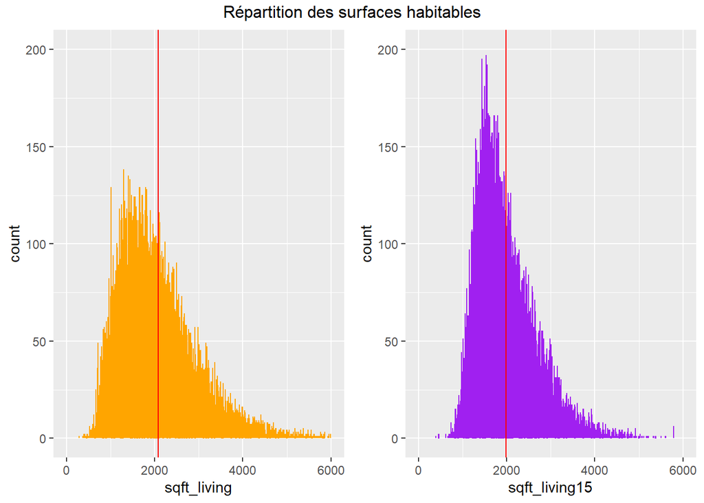

```r
a<-ggplot(data, aes(x=sqft_living))+
  geom_bar(color="orange")+
  xlim(0,6000)+
  ylim(0,200)+
  geom_vline(xintercept=mean(data$sqft_living), color="red")

b<-ggplot(data, aes(x=sqft_living15))+
  geom_bar(color="purple")+
  xlim(0,6000)+
  ylim(0,200)+
  geom_vline(xintercept=mean(data$sqft_living15), color="red")

grid.arrange(a,b, nrow=1, top="Répartition des surfaces habitables")
```

```r
summary(data$sqft_lot)
```

```
##    Min. 1st Qu.  Median    Mean 3rd Qu.    Max.
##     520    5040    7619   15107   10688 1651359
```

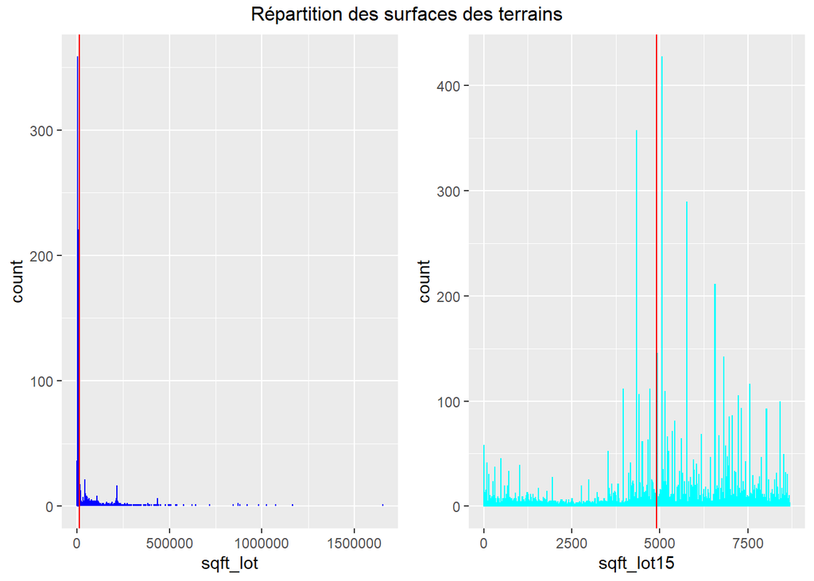

```r
lot <- ggplot(data, aes(x=sqft_lot))+
  geom_bar(color="blue")+
  geom_vline(xintercept=mean(data$sqft_lot), color="red")

lot15 <- ggplot(data, aes(x=sqft_lot15))+
  geom_bar(color="cyan")+
  geom_vline(xintercept=mean(data$sqft_lot15), color="red")

grid.arrange(lot,lot15, nrow=1, top="Répartition des surfaces des terrains")
```

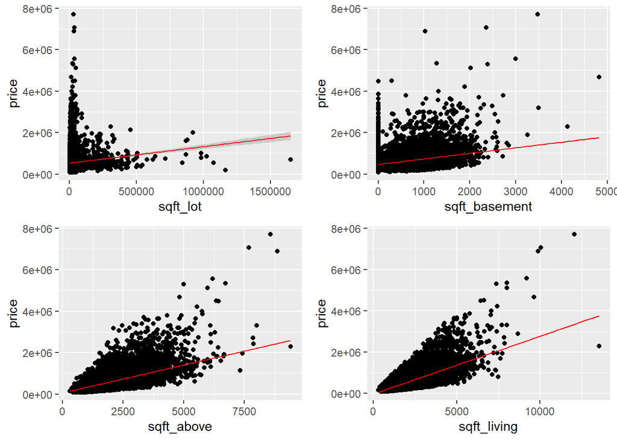

```r
w<-ggplot(data, aes(x=sqft_lot, y=price))+
  geom_point()+
  geom_smooth(method="lm", color = 'red', size = 0.5)

x<-ggplot(data, aes(x=sqft_basement, y=price))+
  geom_point()+
  geom_smooth(method="lm", color = 'red', size = 0.5)


y<-ggplot(data, aes(x=sqft_above, y=price))+
  geom_point()+
  geom_smooth(method="lm", color = 'red', size = 0.5)

z<-ggplot(data, aes(x=sqft_living, y=price))+
  geom_point()+
  geom_smooth(method="lm", color = 'red', size = 0.5)

grid.arrange(w,x,y,z,nrow=2)
```

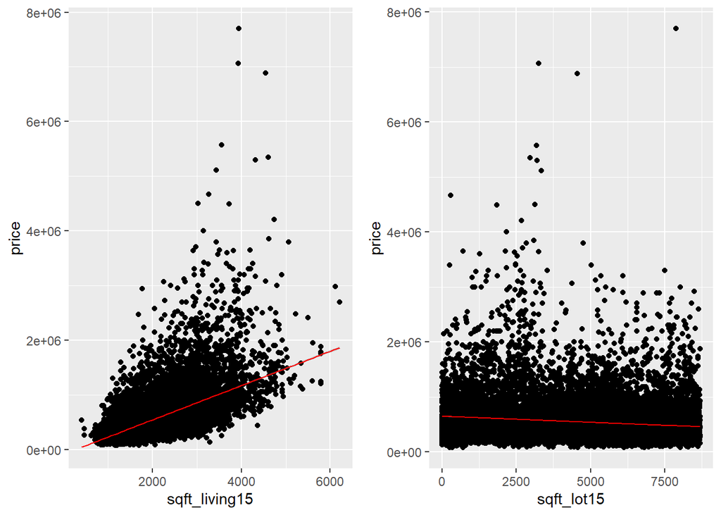

```r
i<-ggplot(data, aes(x=sqft_living15, y=price))+
  geom_point()+
  geom_smooth(method="lm", color = 'red', size = 0.5)

j<-ggplot(data, aes(x=sqft_lot15, y=price))+
  geom_point()+
  geom_smooth(method="lm", color = 'red', size = 0.5)

grid.arrange(i,j, nrow=1)
```

```r
round(prop.table(table(data$condition)),3)
```

```
##
##     1     2     3     4     5
## 0.001 0.008 0.649 0.263 0.079
```

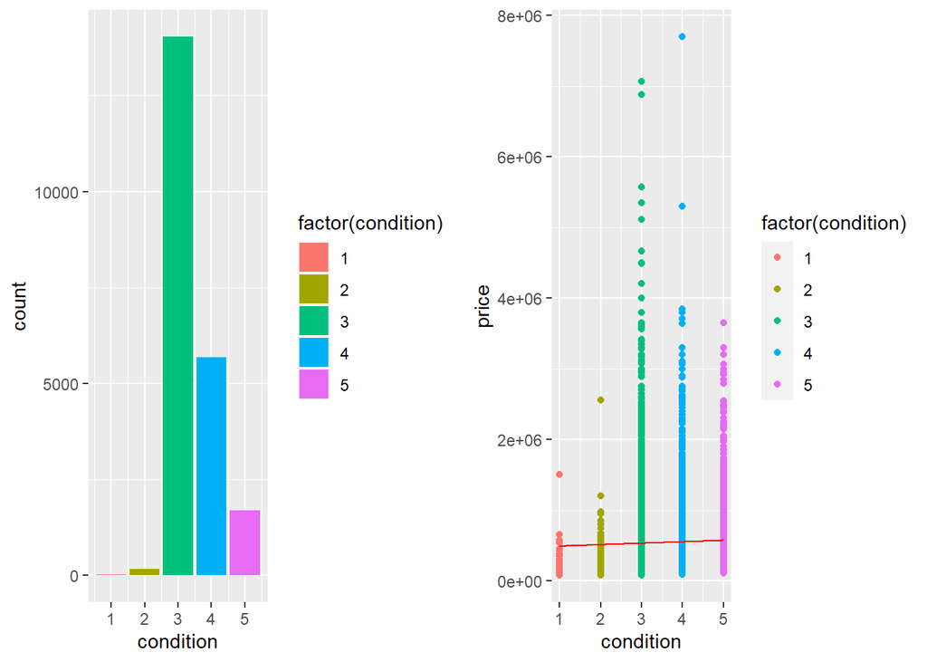

```r
o <- ggplot(data, aes(x=condition))+
  geom_bar(aes(fill=factor(condition)))

p <- ggplot(data, aes(x=condition, y=price))+
  geom_point(aes(colour=factor(condition)))+
  geom_smooth(method="lm", color = 'red', size = 0.5)

grid.arrange(o,p, nrow=1)
```

On voit que l’augmentation de la variable **condition** n’a pas d’effet sur le prix, on ne va donc pas utiliser cette variable.

## Statistiques descriptives axés sur l’emplacement des maisons

D’apres les variables **zipcodes**, **long** et **lat**, l’étude que nous menons sur les maisons se trouve aux alentours de Seattle.

[figure not shown]

```r
include_graphics("Map_Seattle.png")
```

Part des maisons avec vu sur la mer :

```r
mean(data$waterfront)
```

```
## [1] 0.007542106
```

```r
length(data$waterfront[data$waterfront==1])
```

```
## [1] 163
```

Dans notre étude, 0.7% des maisons ont une vue sur la mer soit 163 maisons sur 21613.

On choisit donc de ne pas utiliser la variable car le nombre de maisons ayant vue sur la mer est trop faible par rapport à la base de données.

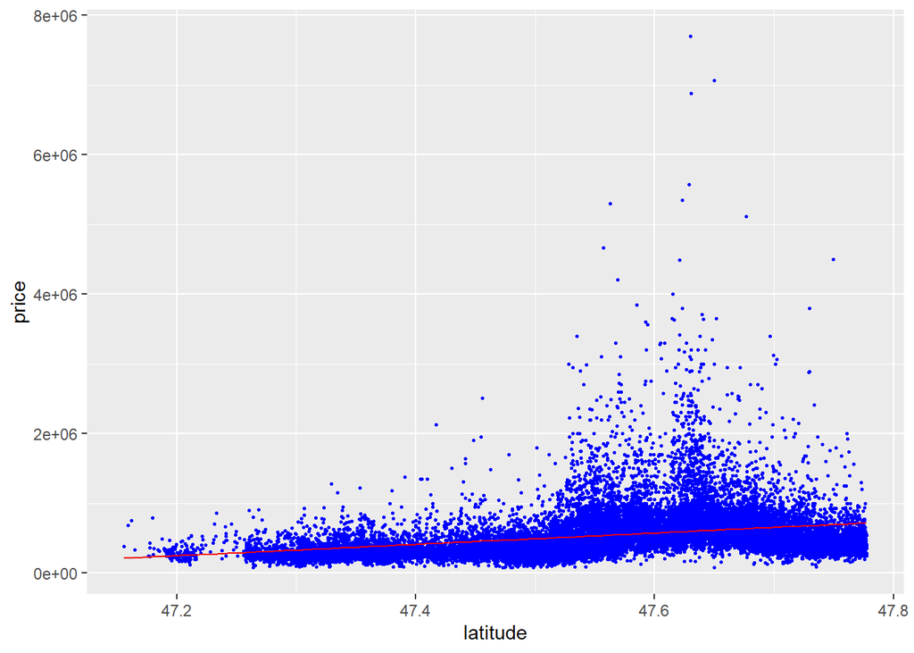

```r
ggplot(data, aes(x=lat, y=price))+
  geom_point(color = 'blue', size = 0.5) +
  geom_smooth(method="lm", color = 'red', size = 0.5) +
  labs(x = 'latitude', y = 'price')
```

Après avoir vu le graphique ainsi que la map de Seattle, on remarque une corrélation positive entre le prix et le fait de s’approcher de la mer et de Seattle.

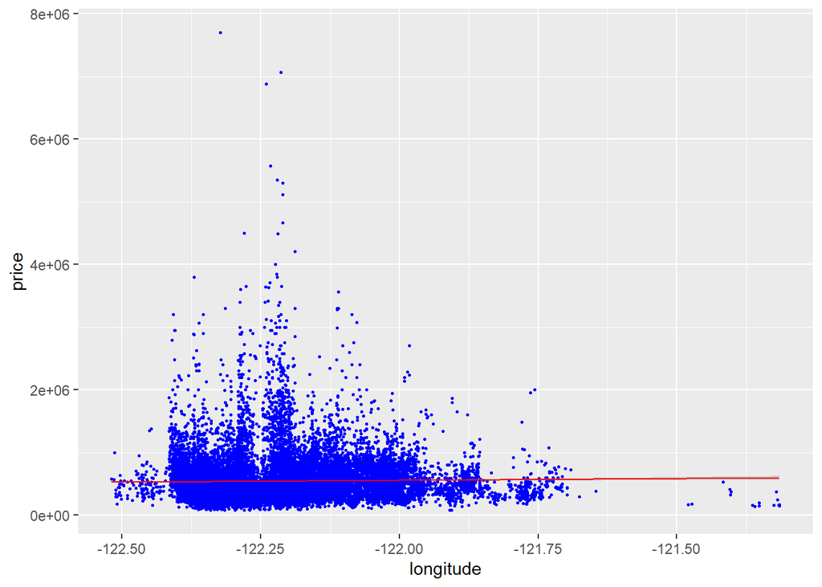

```r
ggplot(data, aes(x=long, y=price))+
  geom_point(color = 'blue', size = 0.5) +
  geom_smooth(method="lm", color = 'red', size = 0.5) +
  labs(x = 'longitude', y = 'price')
```

On remarque aucune tendance particulière du prix en fonction de la longitude, mise a part un pique vers -122.23 représentant probablement un quartier riche.

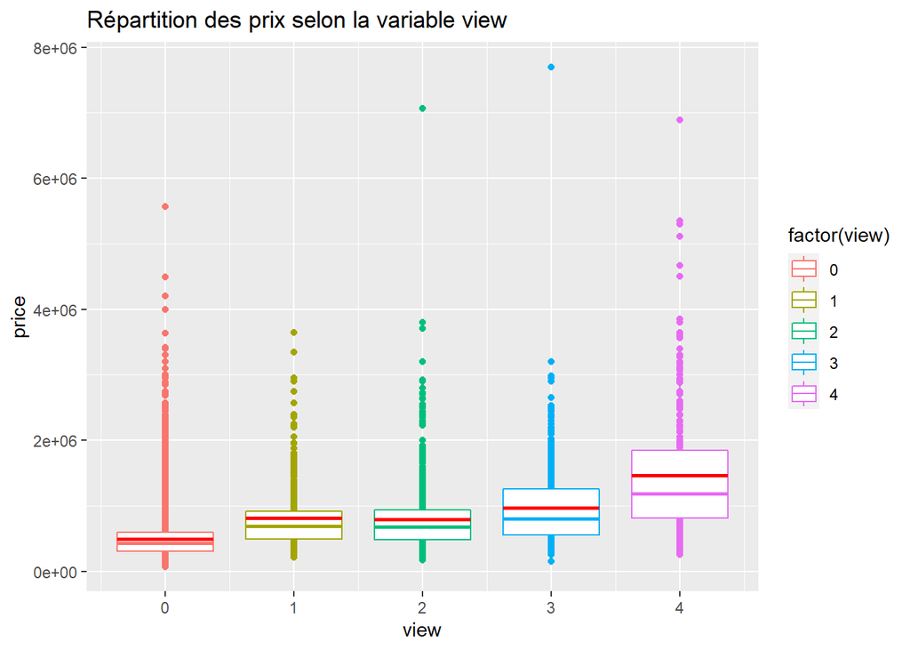

```r
ggplot(data, aes(x=view, y=price))+
  geom_point(aes(colour = factor(view)))+
  geom_boxplot(aes(colour=factor(view)))+
  stat_summary(fun.y="mean", geom="crossbar", size=0.4, width=0.75, color="red")+
  ggtitle("Répartition des prix selon la variable view")
```

On remarque ici que le prix à tendance à augmenter avec la variable **view**.

## Etude des corrélations entre les variables

Dans notre étude, nous allons essayer d’expliquer au maximum la variable **price** correspondant au prix de la maison. Pour cela, nous allons regarder les différentes corrélations et choisir nos variables explicatives en fonction dans nos régréssions.

```r
MatriceCor <- as.dist(round(cor(data),2))
MatriceCor
```

```
##                date price bedrooms bathrooms sqft_living sqft_lot floors
## price          0.00
## bedrooms      -0.02  0.32
## bathrooms     -0.03  0.53     0.53
## sqft_living   -0.03  0.70     0.59      0.75
## sqft_lot       0.01  0.09     0.03      0.09        0.17
## floors        -0.02  0.26     0.18      0.50        0.35    -0.01
## waterfront     0.00  0.27    -0.01      0.06        0.10     0.02   0.02
## view           0.00  0.40     0.08      0.19        0.28     0.07   0.03
## condition     -0.05  0.04     0.03     -0.12       -0.06    -0.01  -0.26
## grade         -0.04  0.67     0.37      0.66        0.76     0.11   0.46
## sqft_above    -0.03  0.61     0.49      0.69        0.88     0.18   0.52
## sqft_basement -0.02  0.32     0.31      0.28        0.44     0.02  -0.25
## yr_built       0.00  0.05     0.16      0.51        0.32     0.05   0.49
## yr_renovated  -0.02  0.13     0.02      0.05        0.06     0.01   0.01
## zipcode        0.00 -0.05    -0.16     -0.19       -0.19    -0.13  -0.04
## lat           -0.03  0.31    -0.01      0.02        0.05    -0.09   0.05
## long          -0.01  0.02     0.13      0.22        0.24     0.23   0.13
## sqft_living15 -0.03  0.59     0.40      0.57        0.76     0.14   0.28
## sqft_lot15     0.02 -0.14     0.03     -0.11       -0.09    -0.08  -0.17
##               waterfront  view condition grade sqft_above sqft_basement
## price
## bedrooms
## bathrooms
## sqft_living
## sqft_lot
## floors
## waterfront
## view                0.40
## condition           0.02  0.05
## grade               0.08  0.25     -0.14
## sqft_above          0.07  0.17     -0.16  0.76
## sqft_basement       0.08  0.28      0.17  0.17      -0.05
## yr_built           -0.03 -0.05     -0.36  0.45       0.42         -0.13
## yr_renovated        0.09  0.10     -0.06  0.01       0.02          0.07
## zipcode             0.03  0.07     -0.01 -0.18      -0.24          0.06
## lat                -0.01  0.01     -0.02  0.11       0.00          0.11
## long               -0.04 -0.08     -0.11  0.20       0.34         -0.14
## sqft_living15       0.09  0.28     -0.09  0.71       0.73          0.20
## sqft_lot15         -0.05 -0.07      0.04 -0.15      -0.08         -0.03
##               yr_built yr_renovated zipcode   lat  long sqft_living15
## price
## bedrooms
## bathrooms
## sqft_living
## sqft_lot
## floors
## waterfront
## view
## condition
## grade
## sqft_above
## sqft_basement
## yr_built
## yr_renovated     -0.22
## zipcode          -0.33         0.06
## lat              -0.15         0.03    0.30
## long              0.41        -0.07   -0.52 -0.14
## sqft_living15     0.33         0.00   -0.27  0.05  0.33
## sqft_lot15       -0.08        -0.02    0.03 -0.08 -0.05         -0.11
```

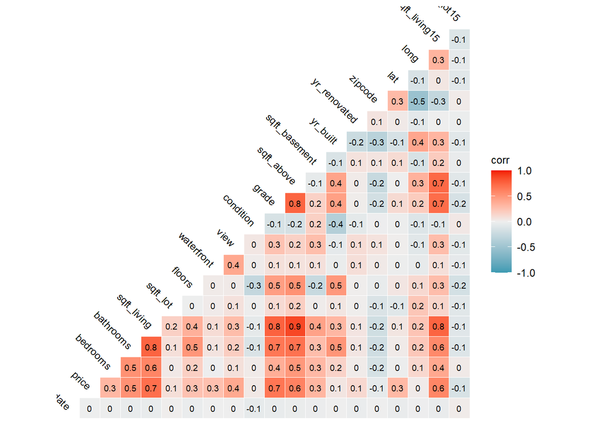

```r
ggcorr(data, name = "corr", label = TRUE, hjust = 1, label_size = 2.5, angle = -45, size = 3)
```

On voit que la variable **price** est :

- très corrélée avec la surface habitable **sqft_living** et la variable **grade** (R² = 0.7)
- bien corrélée avec la surface sans sous-sol **sfqt_above** et la surface habitable en 2015 **sqft_living15** (R² = 0.6) et le nombre de salles de bain **bathrooms** (R² = 0.5)
- moyennement corrélée avec la variable **view** (R² = 0.4), le nombre de chambres **bedrooms**, le nombre d’étages **floors** et la surface du sous-sol **sqft_basement** (R² = 0.3)

# **Régression linéaire 1**

## Régréssion sur la variable living

```r
reg1 <- lm(sqft_living ~ grade + sqft_above + sqft_living15, data=data)
```

```r
summary(reg1)
```

```
##
## Call:
## lm(formula = sqft_living ~ grade + sqft_above + sqft_living15,
##     data = data)
##
## Residuals:
##     Min      1Q  Median      3Q     Max
## -1010.0  -272.7  -134.5   202.7  4985.4
##
## Coefficients:
##                 Estimate Std. Error t value Pr(>|t|)
## (Intercept)   -6.169e+02  2.161e+01  -28.54   <2e-16 ***
## grade          1.266e+02  3.825e+00   33.09   <2e-16 ***
## sqft_above     6.810e-01  5.584e-03  121.94   <2e-16 ***
## sqft_living15  2.567e-01  6.302e-03   40.74   <2e-16 ***
## ---
## Signif. codes:  0 '***' 0.001 '**' 0.01 '*' 0.05 '.' 0.1 ' ' 1
##
## Residual standard error: 403.9 on 21608 degrees of freedom
## Multiple R-squared:  0.8066, Adjusted R-squared:  0.8066
## F-statistic: 3.005e+04 on 3 and 21608 DF,  p-value: < 2.2e-16
```

Le coefficient de détermination vaut 0.8066 c’est à dire que le modèle explique 80.66% de la variabilité de la surface habitable. On peut donc considérer que les variables grade, above et living15 comme faisant parti de la variable living.

On a donc choisit pour notre premiere régréssion les variables les plus corrélées a la variable prix afin d’expliquer au mieux la variabilité du prix.

```r
rlm_1 <- lm(log(price) ~ sqft_living + bedrooms + bathrooms + floors + view + lat, data = data)
summary(rlm_1)
```

```
##
## Call:
## lm(formula = log(price) ~ sqft_living + bedrooms + bathrooms +
##     floors + view + lat, data = data)
##
## Residuals:
##      Min       1Q   Median       3Q      Max
## -3.10564 -0.18159 -0.00883  0.17576  1.28816
##
## Coefficients:
##               Estimate Std. Error t value Pr(>|t|)
## (Intercept) -6.230e+01  6.910e-01  -90.15   <2e-16 ***
## sqft_living  3.366e-04  3.665e-06   91.85   <2e-16 ***
## bedrooms    -2.913e-02  2.811e-03  -10.36   <2e-16 ***
## bathrooms    4.524e-02  4.369e-03   10.35   <2e-16 ***
## floors       2.604e-02  2.168e-03   12.01   <2e-16 ***
## view         1.148e-01  2.757e-03   41.64   <2e-16 ***
## lat          1.568e+00  1.453e-02  107.92   <2e-16 ***
## ---
## Signif. codes:  0 '***' 0.001 '**' 0.01 '*' 0.05 '.' 0.1 ' ' 1
##
## Residual standard error: 0.2948 on 21605 degrees of freedom
## Multiple R-squared:  0.6867, Adjusted R-squared:  0.6867
## F-statistic:  7894 on 6 and 21605 DF,  p-value: < 2.2e-16
```

$price = \beta_0 + \beta_1 bedrooms + \beta_2 bathrooms + \beta_3 floors + \beta_4 view + \beta_5 lat + \beta_6 living + \epsilon_i$

## Analyse de la régréssion linéaire 1

### Analyse des coefficients

**p-value = 2e-16 < alpha = 0.001**

On rejette H0, ce qui signifie que les coefficients associés aux variables **living**, **bedrooms**, **bathrooms**, **floors**, **view** et **lat** sont significativement différents de 0.

# **Régréssion linéaire 2**

```r
rlm_2 <- lm(log(price) ~ bedrooms + bathrooms + floors + view + lat, data = data)
summary(rlm_2)
```

```
##
## Call:
## lm(formula = log(price) ~ bedrooms + bathrooms + floors + view +
##     lat, data = data)
##
## Residuals:
##      Min       1Q   Median       3Q      Max
## -1.91900 -0.22445 -0.01737  0.21060  1.89613
##
## Coefficients:
##               Estimate Std. Error t value Pr(>|t|)
## (Intercept) -66.644486   0.812903  -81.98   <2e-16 ***
## bedrooms      0.063844   0.003092   20.65   <2e-16 ***
## bathrooms     0.276221   0.004213   65.57   <2e-16 ***
## floors        0.028886   0.002556   11.30   <2e-16 ***
## view          0.176810   0.003152   56.09   <2e-16 ***
## lat           1.656730   0.017092   96.93   <2e-16 ***
## ---
## Signif. codes:  0 '***' 0.001 '**' 0.01 '*' 0.05 '.' 0.1 ' ' 1
##
## Residual standard error: 0.3476 on 21606 degrees of freedom
## Multiple R-squared:  0.5644, Adjusted R-squared:  0.5643
## F-statistic:  5600 on 5 and 21606 DF,  p-value: < 2.2e-16
```

$price = \beta_0 + \beta_1 bedrooms + \beta_2 bathrooms + \beta_3 floors + \beta_4 view + \beta_5 lat + \epsilon_i$

## Analyse de la régréssion linéaire 2

### Analyse des coefficients

**p-value = 2e-16 < alpha = 0.001**

On rejette H0, ce qui signifie que les coefficients associés aux variables bedrooms, bathrooms, floors, view et lat sont significativement différents de 0.

### R²

Le coefficient de détermination vaut **0.5644** c’est à dire que le modèle explique 56.44% de la variabilité du prix des maisons.

### Significativité globale du modèle

On s’intéresse ici à la statistique de Fisher pour déterminer la significativité du modèle :

**p-value < 2.2e-16 < alpha = 0.01**

On rejette H0, ce qui signifie que le modèle est globalement significatif.

### Les résidus

Pour que cette régression soit admise, il faut aussi que les résidus respectent certaines conditions. Ils doivent être identiquement distribués de manière aléatoire et donc suivre une loi normale. Ils doivent être homoscédastiques c’est-à-dire que la variance des résidus doit être constante.

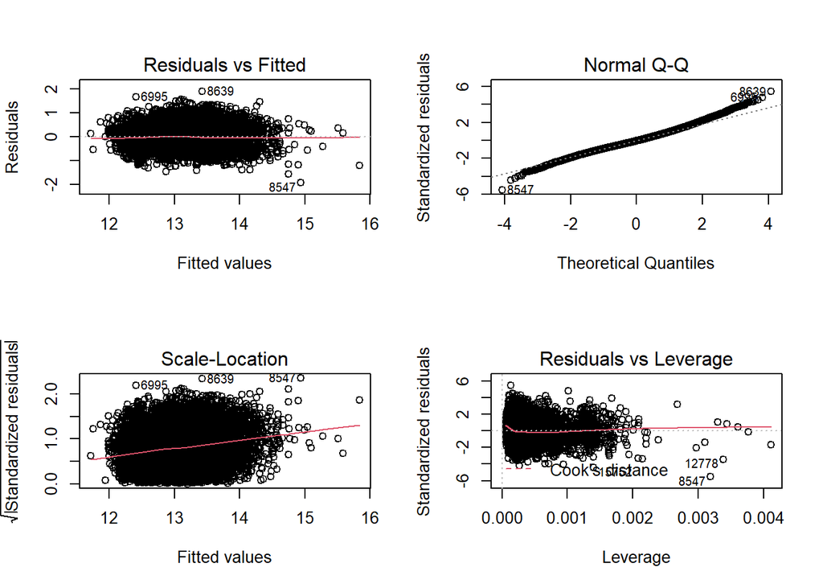

```r
par(mfrow=c(2,2))
plot(rlm_2)
```

- *Normalité*

Pour tester la normalité des résidus, on ne peut pas effectuer de **Shapiro test** car notre nombre d’observations dépasse 5000. On regarde donc le graphique *Normal Q_Q*

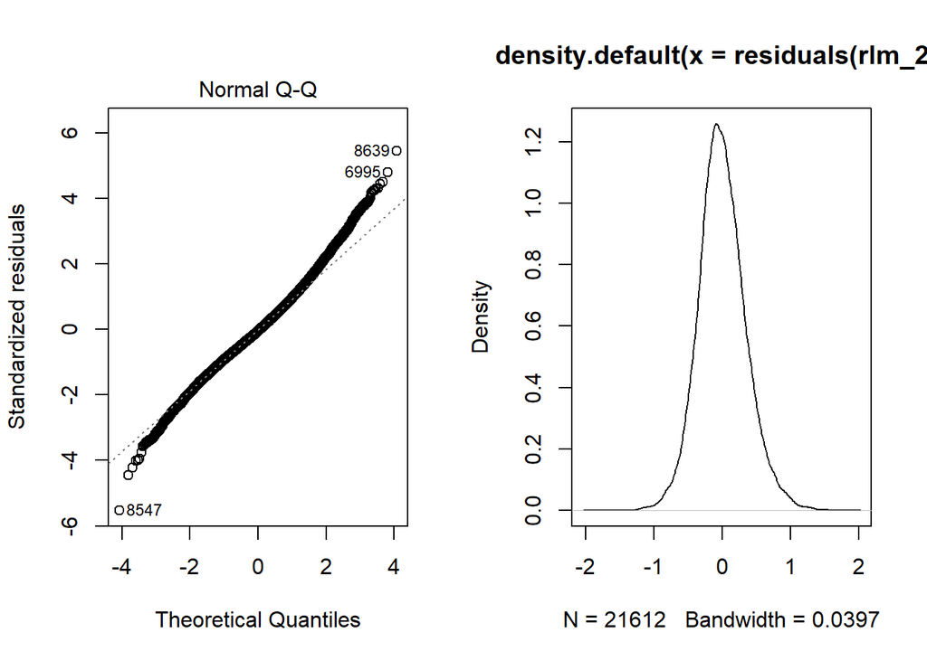

```r
par(mfrow=c(1,2))
plot(rlm_2,2)
plot(density(residuals(rlm_2)))
```

On voit que la distibution des résidus suit approximativement une loi normale. De plus, la densité est plutôt gausiennne, alors on accepte l’hyphothèse de normalité des résidus.

- *Homoscédasticité*

On effectue un test de Breusch-Pagan :

```r
bptest(rlm_2)
```

```
##
##  studentized Breusch-Pagan test
##
## data:  rlm_2
## BP = 606.04, df = 5, p-value < 2.2e-16
```

**p-value < 2.2e-16 < alpha = 0.01**

On rejette donc H0, l’hypothèse d’homoscédasticité, ce qui veut dire que la variance des résidus n’est pas constantes et sont donc hétéroscédastiques.

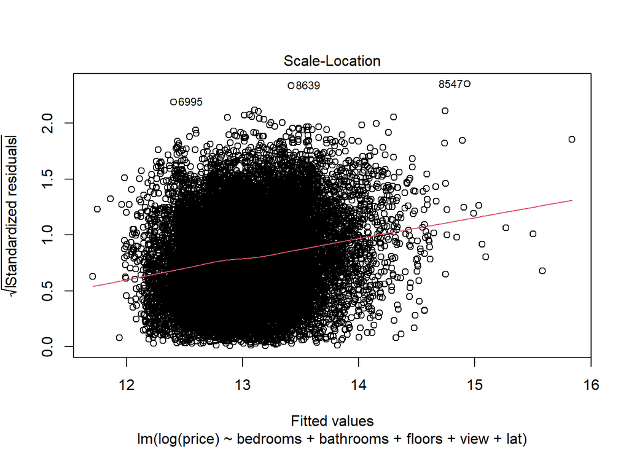

```r
plot(rlm_2,3)
```

De plus, le graphique *Scale-Location* nous montre une certaine tendance, la courbe de tendance n’est pas horizontale.

- *Linéarité*

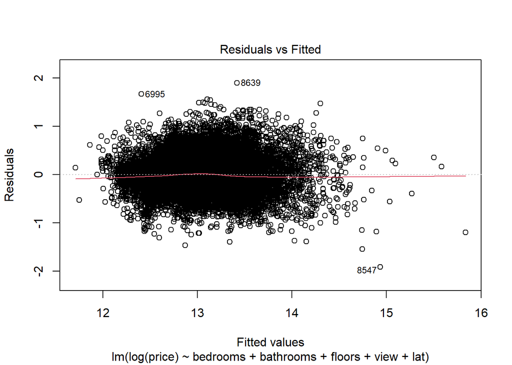

```r
plot(rlm_2,1)
```

Le graphique *Residuals vs Fitted* ne montre pas de regroupement particulier des résidus et la coubre de tendance est horizontale.

On peut donc dire que les résidus sont distribués aléatoirements et qu’ils sont donc indépendants. L’hypothèse de linéarité est donc acceptée.

- *Valeurs aberrantes*

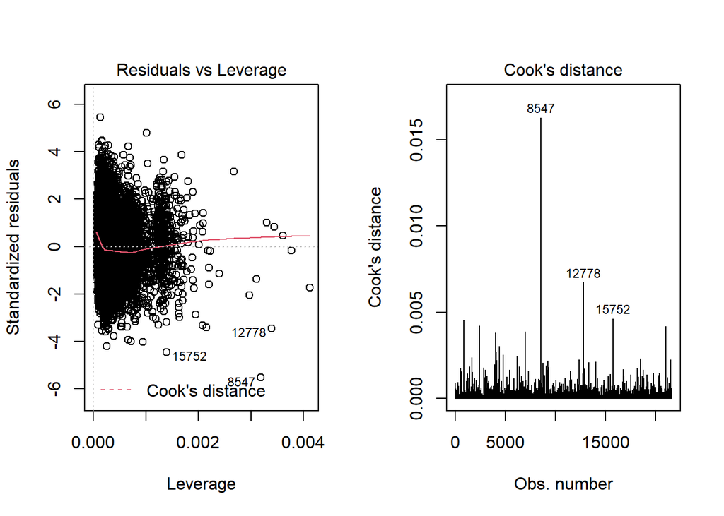

```r
par(mfrow=c(1,2))
plot(rlm_2, 5)
plot(rlm_2, 4)
```

D’après le graphique *Residuals vs Leverage*, nous pouvons conclure qu’il n’y a pas de valeurs aberrantes car la courbe de tendance est proche de 0.

De plus, la distance de Cook n’excède jamais 1 même si il y a des valeurs qui se distinguent ce qui signifie que ces valeurs n’ont pas d’influence.

### Conclusion

Nous pouvons conclure que les résultats du modèle 2 ne peuvent pas être acceptés puisque l’hypothèse d’homoscédasticité est rejetée.

# **Régréssion linéaire 3**

```r
rlm_3 <- lm(log(price) ~ sqft_living + view + lat, data = data)
summary(rlm_3)
```

```
##
## Call:
## lm(formula = log(price) ~ sqft_living + view + lat, data = data)
##
## Residuals:
##      Min       1Q   Median       3Q      Max
## -3.12305 -0.18586 -0.00399  0.18283  1.24468
##
## Coefficients:
##               Estimate Std. Error t value Pr(>|t|)
## (Intercept) -6.279e+01  6.970e-01  -90.08   <2e-16 ***
## sqft_living  3.592e-04  2.307e-06  155.69   <2e-16 ***
## view         1.139e-01  2.761e-03   41.24   <2e-16 ***
## lat          1.578e+00  1.466e-02  107.66   <2e-16 ***
## ---
## Signif. codes:  0 '***' 0.001 '**' 0.01 '*' 0.05 '.' 0.1 ' ' 1
##
## Residual standard error: 0.2982 on 21608 degrees of freedom
## Multiple R-squared:  0.6795, Adjusted R-squared:  0.6794
## F-statistic: 1.527e+04 on 3 and 21608 DF,  p-value: < 2.2e-16
```

$price = \beta_0 + \beta_1 sqftliving+ \beta_2 view + \beta_3 lat + \epsilon_i$

## Analyse de la régréssion linéaire 3

### Analyse des coefficients

**p-value = 2e-16 < alpha = 0.001**

On rejette H0, ce qui signifie que les coefficients associés aux variables living, view et lat sont significativement différents de 0.

- Une augmentation de la variable living d’une unité augmente le prix de 0.03592%.
- Une augmentation de la variable view d’une unité augmente le prix de 11.39%.
- Une augmentation de 0.01 unité de latitude augmente le prix de 1.57%

### R²

Le coefficient de détermination vaut **0.6795** c’est à dire que le modèle explique 67.95% de la variabilité du prix des maisons.

### Significativité globale du modèle

On s’intéresse ici à la statistique de Fisher pour déterminer la significativité du modèle :

**p-value < 2.2e-16 < alpha = 0.01**

On rejette H0, ce qui signifie que le modèle est globalement significatif.

### Les résidus

Pour que cette régression soit admise, il faut aussi que les résidus respectent certaines conditions. Ils doivent être identiquement distribués de manière aléatoire et donc suivre une loi normale. Ils doivent être homoscédastiques c’est-à-dire que la variance des résidus doit être constante.

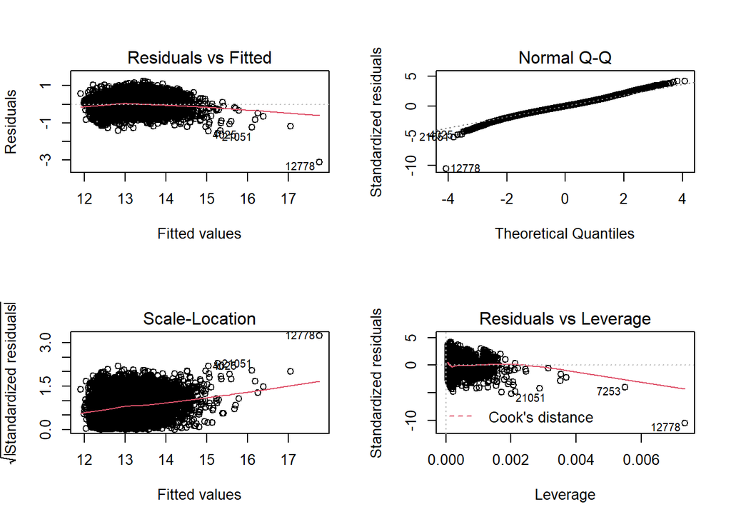

```r
par(mfrow=c(2,2))
plot(rlm_3)
```

- *Normalité*

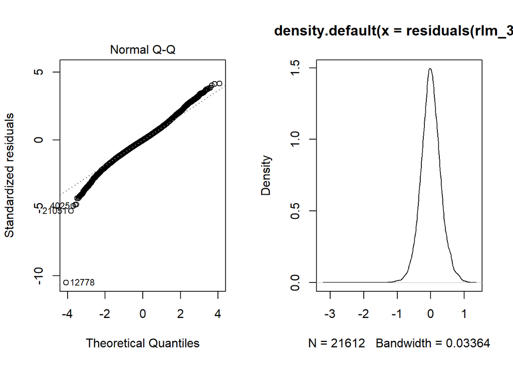

```r
par(mfrow=c(1,2))
plot(rlm_3, 2)
plot(density(residuals(rlm_3)))
```

On voit que la distibution des résidus suit approximativement une loi normale. De plus, la densité est plutôt gausiennne, alors on accepte l’hyphothèse de normalité des résidus.

- *Homoscédasticité*

On effectue un test de Breusch-Pagan :

```r
bptest(rlm_3)
```

```
##
##  studentized Breusch-Pagan test
##
## data:  rlm_3
## BP = 763.13, df = 3, p-value < 2.2e-16
```

**p-value < 2.2e-16 < alpha = 0.01**

On rejette donc H0, l’hypothèse d’homoscédasticité, ce qui veut dire que la variance des résidus n’est pas constantes et sont donc hétéroscédastiques.

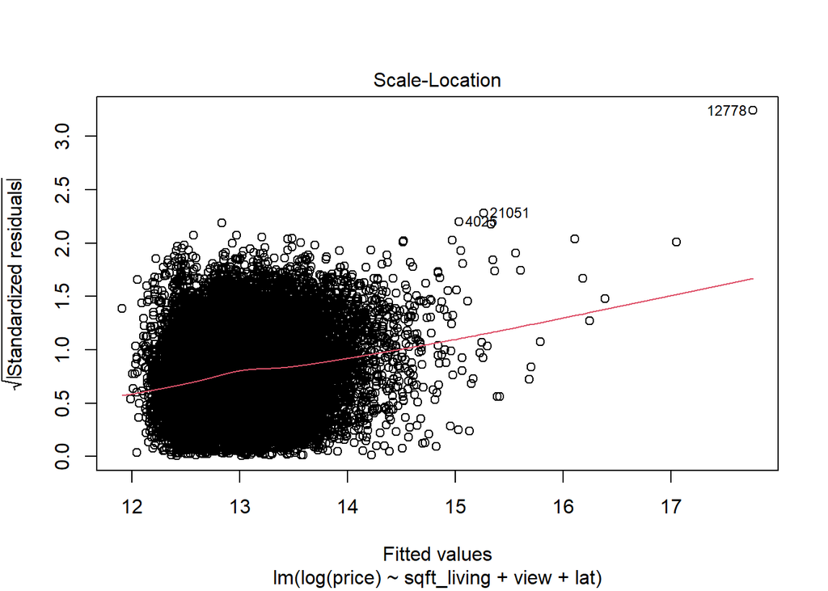

```r
plot(rlm_3, 3)
```

De plus, le graphique *Scale-Location* nous montre une certaine tendance, la droite rouge n’est pas horizontale.

- *linéarité*

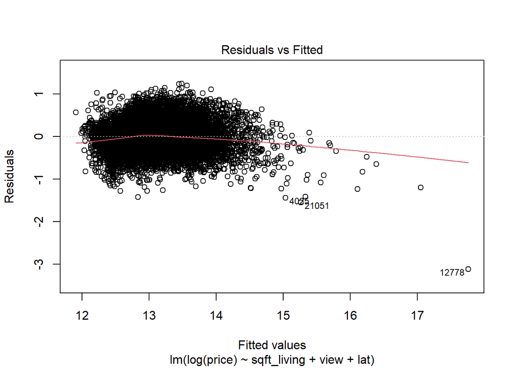

```r
plot(rlm_3, 1)
```

- *Valeurs aberantes*

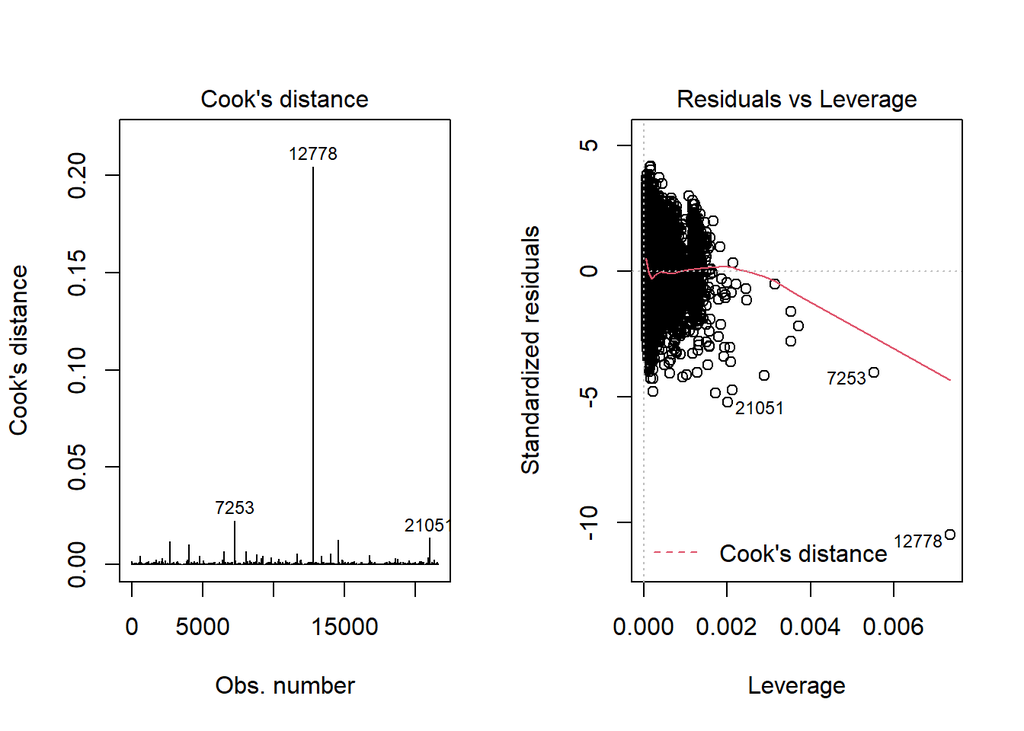

```r
par(mfrow=c(1,2))
plot(rlm_3, 4)
plot(rlm_3, 5)
```

De plus, la distance de Cook n’excède jamais 1 même si il y a des valeurs qui se distinguent ce qui signifie que ces valeurs n’ont pas d’influence.

### Conclusion

Cette régréssion ne peut pas être accepté bien que son R^2 soit de 68%, les hypothèses d’homoscédasticité et de linéarité ne sont pas vérifiées.

# Régression linéaire 4

Pour cette quatrième et dernière régression, nous avons voulu nous intéresser à la variable **grade** qui est l’une des plus corrélée avec le prix. Le prix étant exponentiel avec cette variable.

Après avoir cherché divers moyens pour améliorer notre modèle, nous avons décidé de séparer la variable **grade** en variables dummy.

```r
data$grade3 <- as.numeric(data$grade==3)
data$grade4 <- as.numeric(data$grade==4)
data$grade5 <- as.numeric(data$grade==5)
data$grade6 <- as.numeric(data$grade==6)
data$grade7 <- as.numeric(data$grade==7)
data$grade8 <- as.numeric(data$grade==8)
data$grade9 <- as.numeric(data$grade==9)
data$grade10 <- as.numeric(data$grade==10)
data$grade11 <- as.numeric(data$grade==11)
data$grade12 <- as.numeric(data$grade==12)
data$grade13 <- as.numeric(data$grade==13)
```

```r
rlm_final <- lm(log(price) ~ grade6 + grade7 + grade8 + grade9 + grade10 + grade11 + grade12 + grade13 + bathrooms + view, data=data)

summary(rlm_final)
```

```
##
## Call:
## lm(formula = log(price) ~ grade6 + grade7 + grade8 + grade9 +
##     grade10 + grade11 + grade12 + grade13 + bathrooms + view,
##     data = data)
##
## Residuals:
##      Min       1Q   Median       3Q      Max
## -1.33413 -0.25825  0.00238  0.23426  1.42274
##
## Coefficients:
##              Estimate Std. Error t value Pr(>|t|)
## (Intercept) 12.179890   0.022068 551.920   <2e-16 ***
## grade6       0.228703   0.023002   9.943   <2e-16 ***
## grade7       0.462052   0.022143  20.866   <2e-16 ***
## grade8       0.692200   0.022722  30.464   <2e-16 ***
## grade9       0.989869   0.023688  41.788   <2e-16 ***
## grade10      1.244028   0.025466  48.851   <2e-16 ***
## grade11      1.477927   0.030010  49.248   <2e-16 ***
## grade12      1.736683   0.045415  38.240   <2e-16 ***
## grade13      2.117243   0.103140  20.528   <2e-16 ***
## bathrooms    0.099751   0.004272  23.350   <2e-16 ***
## view         0.120439   0.003307  36.420   <2e-16 ***
## ---
## Signif. codes:  0 '***' 0.001 '**' 0.01 '*' 0.05 '.' 0.1 ' ' 1
##
## Residual standard error: 0.3579 on 21601 degrees of freedom
## Multiple R-squared:  0.5385, Adjusted R-squared:  0.5383
## F-statistic:  2521 on 10 and 21601 DF,  p-value: < 2.2e-16
```

```r
rlm_final2 <- lm(log(price) ~ grade8 + grade9 + grade10 + grade11 + grade12 + grade13 + bathrooms + view, data=data)

summary(rlm_final2)
```

```
##
## Call:
## lm(formula = log(price) ~ grade8 + grade9 + grade10 + grade11 +
##     grade12 + grade13 + bathrooms + view, data = data)
##
## Residuals:
##      Min       1Q   Median       3Q      Max
## -1.39656 -0.26192  0.00236  0.23973  1.42634
##
## Coefficients:
##              Estimate Std. Error t value Pr(>|t|)
## (Intercept) 12.522393   0.007899 1585.41   <2e-16 ***
## grade8       0.258684   0.006424   40.27   <2e-16 ***
## grade9       0.544270   0.008945   60.85   <2e-16 ***
## grade10      0.785388   0.012737   61.66   <2e-16 ***
## grade11      1.000454   0.020296   49.29   <2e-16 ***
## grade12      1.241279   0.040161   30.91   <2e-16 ***
## grade13      1.578722   0.102668   15.38   <2e-16 ***
## bathrooms    0.138630   0.004170   33.24   <2e-16 ***
## view         0.119292   0.003381   35.28   <2e-16 ***
## ---
## Signif. codes:  0 '***' 0.001 '**' 0.01 '*' 0.05 '.' 0.1 ' ' 1
##
## Residual standard error: 0.3659 on 21603 degrees of freedom
## Multiple R-squared:  0.5175, Adjusted R-squared:  0.5173
## F-statistic:  2896 on 8 and 21603 DF,  p-value: < 2.2e-16
```

```r
rlm_final3 <- lm(log(price) ~ grade4 + grade5 + grade6 + grade7 + grade8 + grade9 + grade10 + grade11 + grade12 + grade13 + bathrooms + view, data=data)

summary(rlm_final3)
```

```
##
## Call:
## lm(formula = log(price) ~ grade4 + grade5 + grade6 + grade7 +
##     grade8 + grade9 + grade10 + grade11 + grade12 + grade13 +
##     bathrooms + view, data = data)
##
## Residuals:
##      Min       1Q   Median       3Q      Max
## -1.33428 -0.25813  0.00235  0.23418  1.42292
##
## Coefficients:
##              Estimate Std. Error t value Pr(>|t|)
## (Intercept) 12.008199   0.178932  67.110  < 2e-16 ***
## grade4       0.062616   0.190897   0.328 0.742908
## grade5       0.187826   0.180447   1.041 0.297935
## grade6       0.400623   0.179163   2.236 0.025356 *
## grade7       0.634081   0.179107   3.540 0.000401 ***
## grade8       0.864325   0.179228   4.823 1.43e-06 ***
## grade9       1.162053   0.179382   6.478 9.49e-11 ***
## grade10      1.416275   0.179658   7.883 3.34e-15 ***
## grade11      1.650267   0.180405   9.148  < 2e-16 ***
## grade12      1.909113   0.183642  10.396  < 2e-16 ***
## grade13      2.289879   0.205756  11.129  < 2e-16 ***
## bathrooms    0.099566   0.004273  23.300  < 2e-16 ***
## view         0.120437   0.003307  36.420  < 2e-16 ***
## ---
## Signif. codes:  0 '***' 0.001 '**' 0.01 '*' 0.05 '.' 0.1 ' ' 1
##
## Residual standard error: 0.3579 on 21599 degrees of freedom
## Multiple R-squared:  0.5386, Adjusted R-squared:  0.5383
## F-statistic:  2101 on 12 and 21599 DF,  p-value: < 2.2e-16
```

$price = \beta_0 + \beta_1 grade6 + \beta_2 grade7 + \beta_3 grade8 + \beta_4 grade9 + \beta_5 grade10 + \beta_6 grade11 + \beta_7 grade12 + \beta_8 grade13 + \beta_9 bathrooms + \beta_10 view+ \epsilon_i$

On a choisi pour cette régréssion d’enlever les grade 3 a 5 du fait qu’elles ne sont pas très nombreuses et qu’lles ne sont pas très significatives vis a vis du prix.

## **Analyse de la régression linéaire 4**

### Analyse des coefficients

**p-value = 2e-16 < alpha = 0.001**

On rejette H0, ce qui signifie que les coefficients associés aux variables grade6 a grade13, view et bathrooms sont significativement différents de 0.

### R²

Le coefficient de détermination vaut **0.5385** c’est à dire que le modèle explique 53.85% de la variabilité du prix des maisons.

### Significativité globale du modèle

On s’intéresse ici à la statistique de Fisher pour déterminer la significativité du modèle :

**p-value < 2.2e-16 < alpha = 0.01**

On rejette H0, ce qui signifie que le modèle est globalement significatif.

### Les résidus

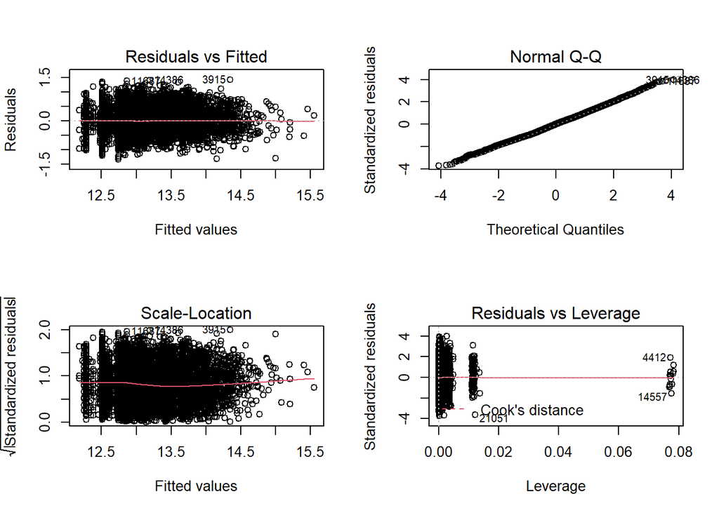

```r
par(mfrow=c(2,2))
plot(rlm_final)
```

- *Normalité*

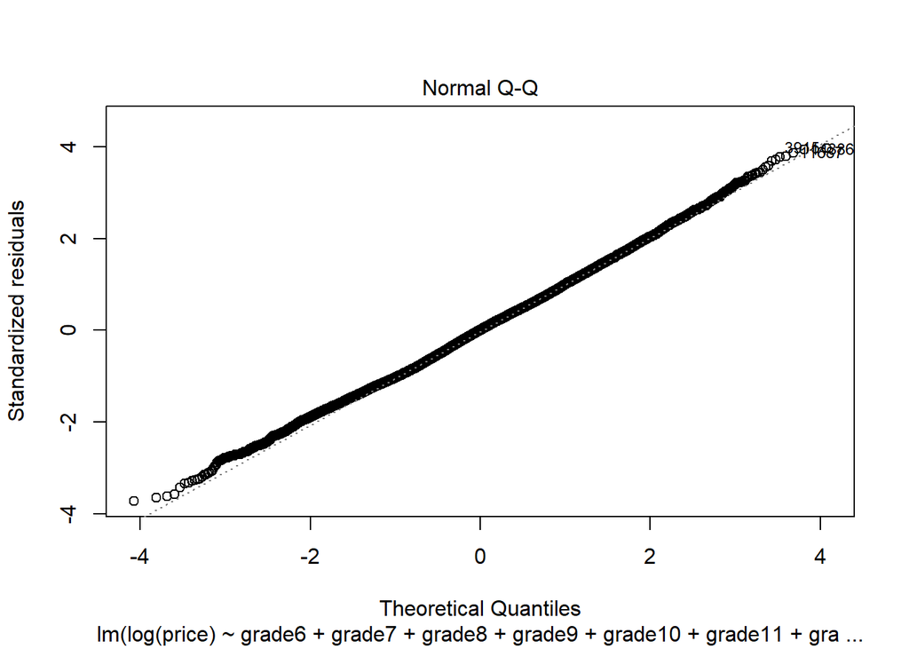

```r
plot(rlm_final,2)
```

On voit bien que les résidus suivent une distribution normale.

- *Homoscédasticité*

On effectue un test de Breusch-Pagan :

```r
bptest(rlm_final)
```

```
##
##  studentized Breusch-Pagan test
##
## data:  rlm_final
## BP = 127.87, df = 10, p-value < 2.2e-16
```

**p-value < 2.2e-16 < alpha = 0.01**

On rejette donc H0, l’hypothèse d’homoscédasticité, ce qui veut dire que la variance des résidus n’est pas constantes et sont donc hétéroscédastiques.

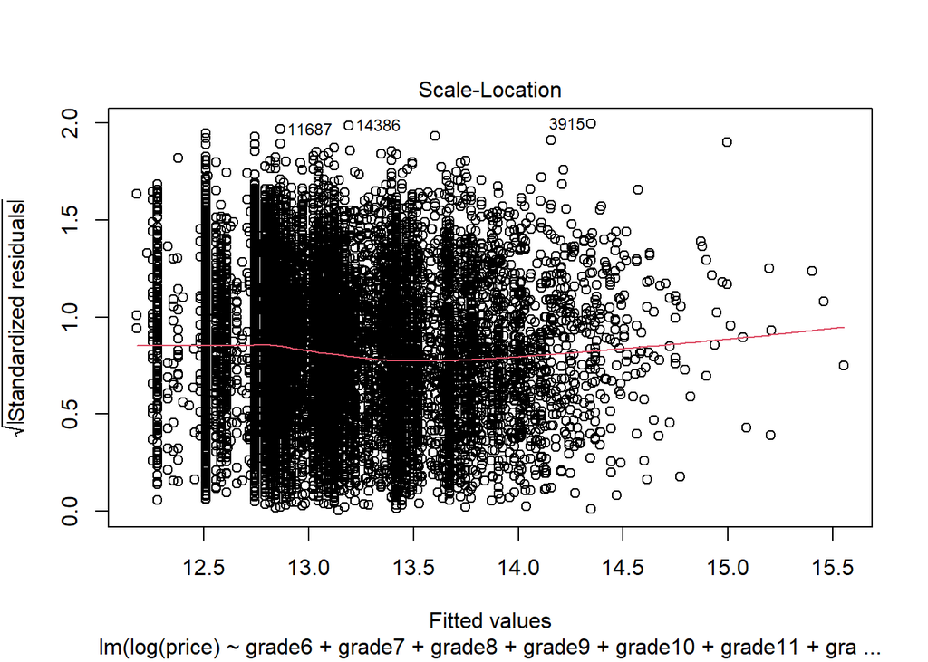

```r
plot(rlm_final,3)
```

La tendance du graphique *Scale-Location* reste cependant plus acceptable que dans nos autres régréssions, la courbe de tendance est presque horizontale.

- *Linéarité*

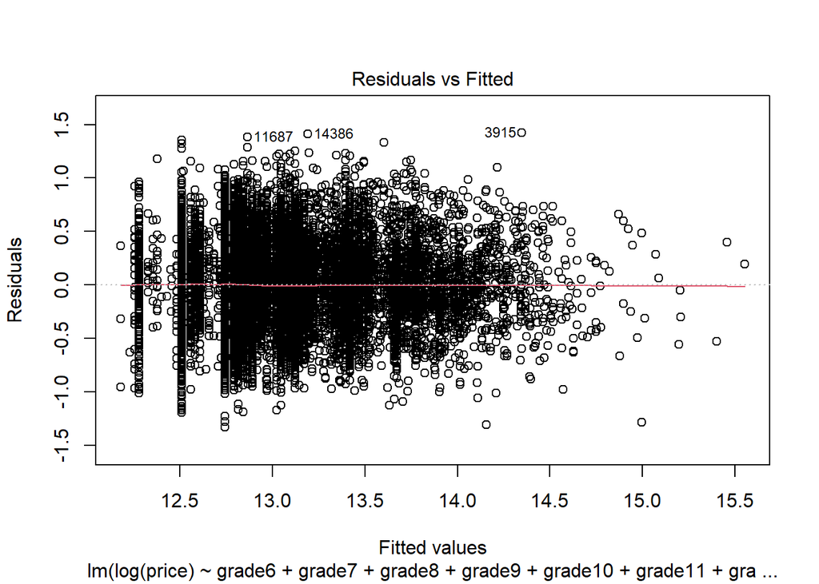

```r
plot(rlm_final, 1)
```

Le graphique *Residuals vs Fitted* montre quelques regroupements des résidus, mais ces groupements sont dus au caractère discret de la variable **grade**. On voit que la courbe de tendance est une droite horizontale.

Alors on accepte tout de même l’hypothèse de linéarité comme quoi les résidus sont distribués de manière aléatoire et qu’ils sont indépendants.

- *Valeurs abérrantes*

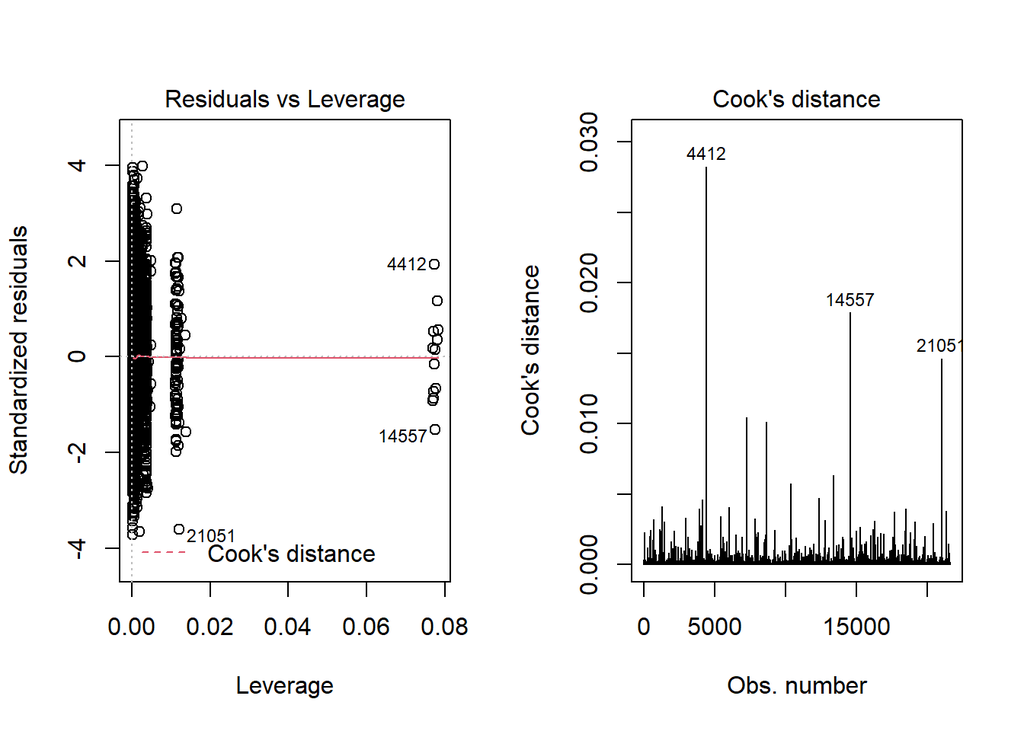

```r
par(mfrow=c(1,2))
plot(rlm_final, 5)
plot(rlm_final, 4)
```

D’après le graphique *Residuals vs Leverage*, nous pouvons conclure qu’il n’y a pas de valeurs aberrantes car la courbe de tendance est proche de 0.

De plus, la distance de Cook n’excède jamais 1 même si il y a des valeurs qui se distinguent ce qui signifie que ces valeurs n’ont pas d’influence.

### Conclusion

On en conclut que les résultats de notre quatrième régression ne peuvent pas être acceptés car l’hypothèse d’homoscédasticité est rejetée.

# **Conclusion de l’étude**

Pour conclure, nos différentes expérimentations pour expliquer au mieux la variabilité du prix de vente des maisons ne peuvent être retenues en raison des hypothèses sur les résidus.

Elles sont tout de même de plus en plus acceptables au fil de nos régréssions. Avec le dernier modèle on arrive à une quasi-parfaite normalité des résidus mais le test de Breusch-Pagan rejette l’homoscédasticité même si la tendance du graphique *Scale-Location* tend à être horizontale.

Les résultats de nos modèles ne peuvent donc être acceptés malgrès des R² assez élevés et de nombreuses variables correlées avec le prix.